# Lab 06

Math 6040/7260 Linear Models

Dr. Xiang Ji @ Tulane University

## Goal of this lab session

We practice the diagnostic tools and data transformation using Canadian Survey of Labour and Income Dynamics (SLID). We want to replicate the analysis in Chapter 12 in JF.

### Preparations

Let’s first load the data.

```r
slid.data <- read.table("SLID-Ontario.txt", header = TRUE)
# show dimension
dim(slid.data)
```

```
## [1] 3997    4
```

### Fit linear model in 12.1

$$Wage = \beta_0 + \beta_1 \cdot Sex + \beta_2 \cdot Age + \beta_3 \cdot
Education + \epsilon$$

```r
lmod <- lm(compositeHourlyWages ~ sex + age + yearsEducation, data = slid.data)
summary(lmod)
```

```
##
## Call:
## lm(formula = compositeHourlyWages ~ sex + age + yearsEducation,
##     data = slid.data)
##
## Residuals:
##     Min      1Q  Median      3Q     Max
## -26.490  -4.302  -0.746   3.233  35.871
##
## Coefficients:
##                 Estimate Std. Error t value Pr(>|t|)
## (Intercept)    -8.124231   0.598977  -13.56   <2e-16 ***
## sexMale         3.473670   0.207009   16.78   <2e-16 ***
## age             0.261293   0.008664   30.16   <2e-16 ***
## yearsEducation  0.929649   0.034257   27.14   <2e-16 ***
## ---
## Signif. codes:  0 '***' 0.001 '**' 0.01 '*' 0.05 '.' 0.1 ' ' 1
##
## Residual standard error: 6.542 on 3993 degrees of freedom
## Multiple R-squared:  0.3074, Adjusted R-squared:  0.3069
## F-statistic: 590.7 on 3 and 3993 DF,  p-value: < 2.2e-16
```

## Q.1

### Write out the parameter estimates.

**Answer**:
$$\begin{aligned}
\hat{\beta_0} &= -8.124\\
\hat{\beta_1} &= 3.474\\
\hat{\beta_2} &= 0.261\\
\hat{\beta_3} &= 0.930\\
\end{aligned}$$
### Write out the associated hypothesis tests for each p-values in the above summary table

The hypothesis test for $\beta_i$ is
$$\begin{aligned}
H_0: &\beta_i = 0 \\
&\mbox{ v.s. }\\
H_a: &\beta_i \ne 0
\end{aligned}$$

### What is the $R^2$ value?

$$R^2 = 0.3074$$

## Q2, Replicate Figure 12.1 (a) Quantile-comparison plot for the studentized residuals from the SLID regression.

```r
library(car)
```

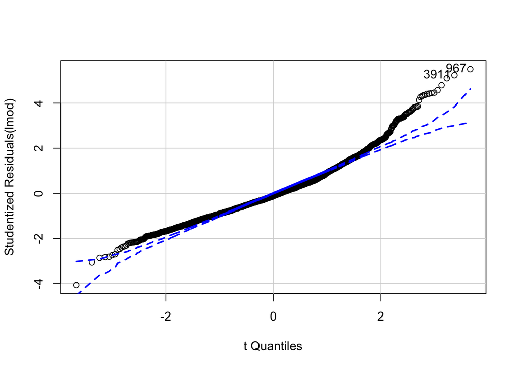

```
## [1]  967 3911
```

```r
qqPlot(lmod, distribution = "t", line = "none", envelop = list(style = "lines"))
```

## Q3

### Fit another linear regression with log2 (base 2) transformed wage as the response variable.

$$\log_2(Wage) = \beta_0' + \beta_1' \cdot Sex + \beta_2'
\cdot Age + \beta_3' \cdot Education + \epsilon'$$

```r
lmod.2 <- lm(log2(compositeHourlyWages) ~ sex + age + yearsEducation, data = slid.data)
summary(lmod.2)
```

```
##
## Call:
## lm(formula = log2(compositeHourlyWages) ~ sex + age + yearsEducation,
##     data = slid.data)
##
## Residuals:
##     Min      1Q  Median      3Q     Max
## -3.4470 -0.3992  0.0189  0.4099  2.2606
##
## Coefficients:
##                 Estimate Std. Error t value Pr(>|t|)
## (Intercept)    1.5855472  0.0547718   28.95   <2e-16 ***
## sexMale        0.3238792  0.0189294   17.11   <2e-16 ***
## age            0.0261919  0.0007923   33.06   <2e-16 ***
## yearsEducation 0.0806127  0.0031325   25.73   <2e-16 ***
## ---
## Signif. codes:  0 '***' 0.001 '**' 0.01 '*' 0.05 '.' 0.1 ' ' 1
##
## Residual standard error: 0.5982 on 3993 degrees of freedom
## Multiple R-squared:  0.3212, Adjusted R-squared:  0.3207
## F-statistic: 629.7 on 3 and 3993 DF,  p-value: < 2.2e-16
```

### Report $R^2$ value

$$R^2 = 0.3212$$

### Replicate Figure 12.2 (a)

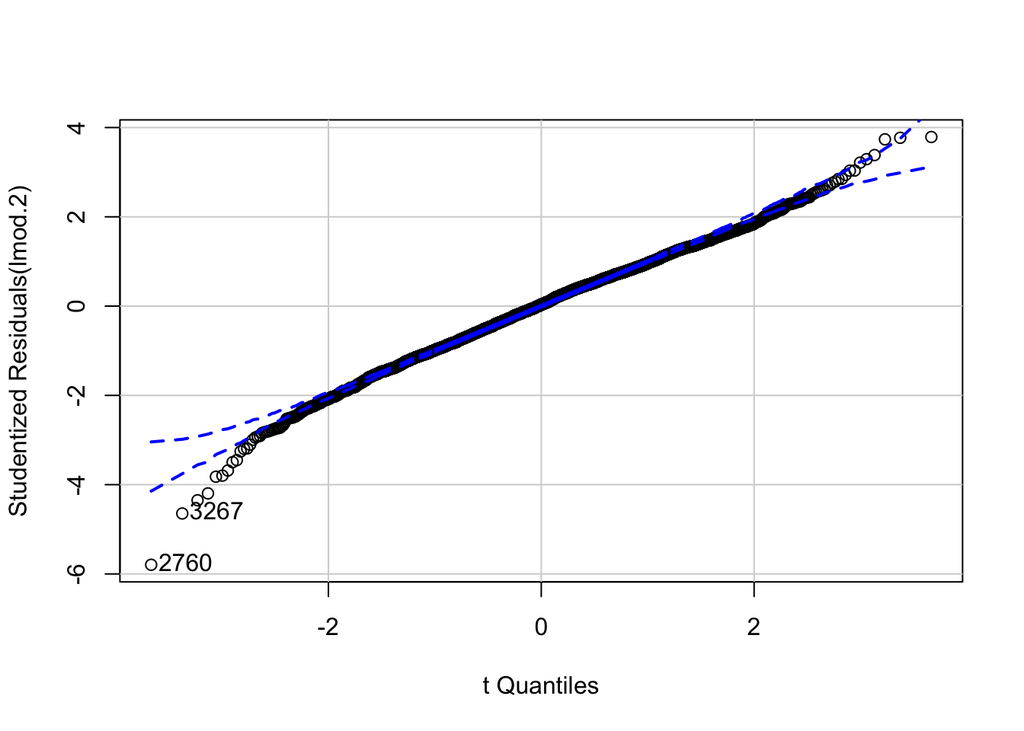

```
## [1] 2760 3267
```

```r
qqPlot(lmod.2, distribution = "t", line = "none",
       envelop = list(style = "lines", col = 1, alpha = 0.1))
```

### Has the transformation corrected the positive skew in the original regression model?

**Answer**: Yes. A positive skew in the residuals can usually be corrected by moving the **response** variable down the ladder of powers and roots.

## Q4

### Replicate Figure 12.3 (a) of Studentized residuals versus fitted values from the first model (without data transformation)

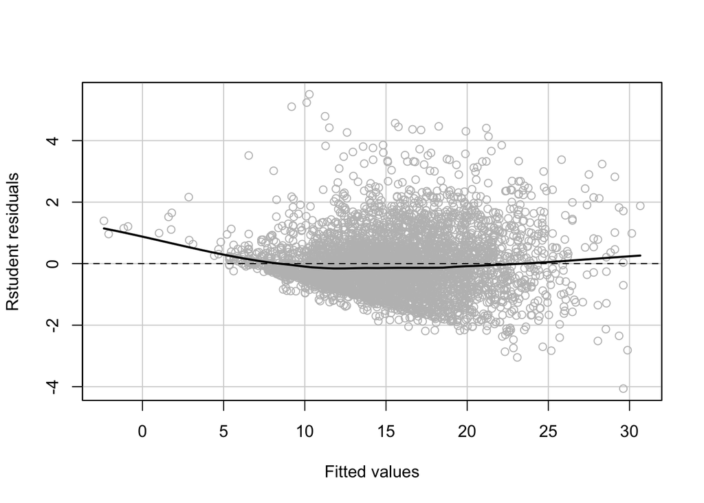

```r
residualPlot(lmod, variable = "fitted", type = "rstudent", col = "grey",
             smooth = list(smoother=loessLine, span = 0.4, col = "black"),
             quadratic = FALSE)
```

### Replicate Figure 12.4 (a) of studentized residuals versus fitted values from the second model (with log2 transformed wage)

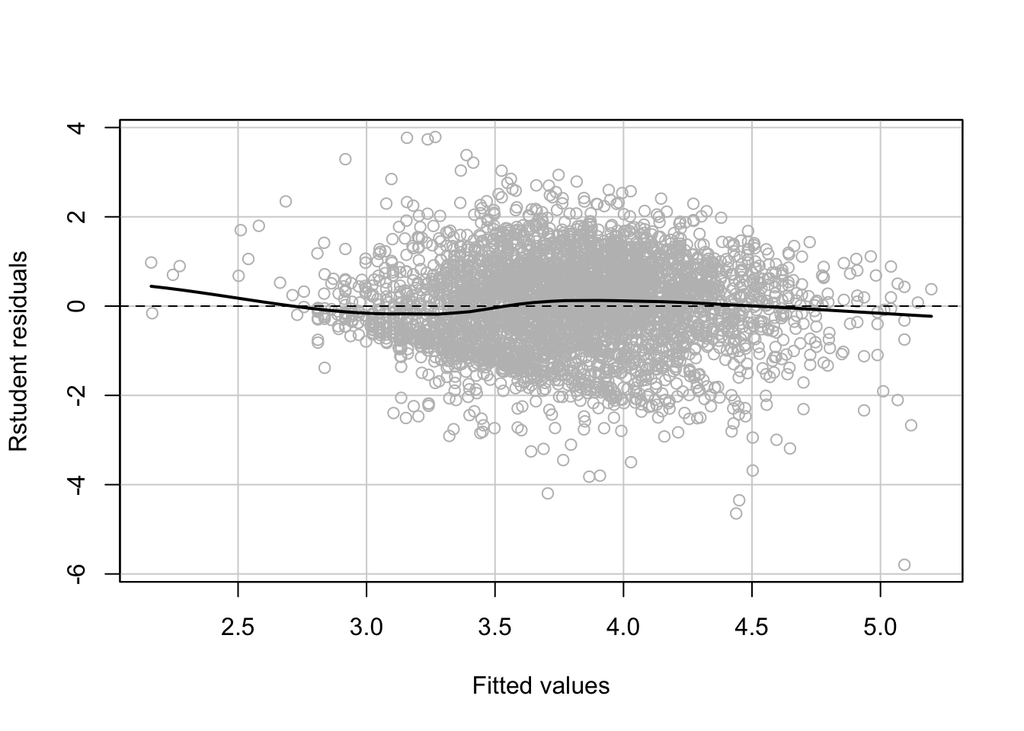

```r
residualPlot(lmod.2, variable = "fitted", type = "rstudent", col = "grey",
             smooth = list(smoother=loessLine, span = 0.4, col = "black"),
             quadratic = FALSE)
```

### Comment on your findings from the last two plots

**Answer**: (from JF 12.2.1) The log transformation of wages made the distribution of studentized residuals more symmetric (as shown in the Quantile-comparison plot). The same transformation approximately stabilizes the residual variance, as illustrated in the above plots. This outcome is not surprising because the heavy right tail of the residual distribution and nonconstant sppread are both common consequences of the lower bound of $0$ for the response variable.

Transforming $Y$ changes the shape of the error distribution, but it also alters the shape of the regression of $Y$ on the $X$s. At times, eliminating nonconstant spread also makes the relationship of $Y$ to the $X$s more nearly linear, but this is not a necessary consequence of stabilizing the response variable. Of course, because there is generally no reason to suppose that the regression is linear **prior** to transforming $Y$, we should check for nonlinearity in any event.

## Q5

### Replicate Figure 12.6, Component-plus-residual plots for age and education

in the SLID regression of log wages on these variables and sex.

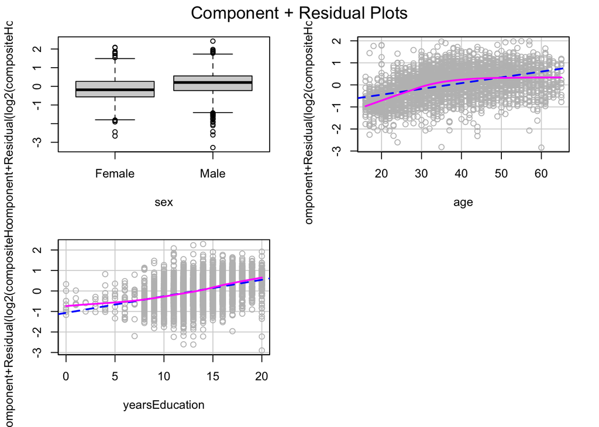

```r
# plot all together
crPlots(lmod.2, col = "grey")
```

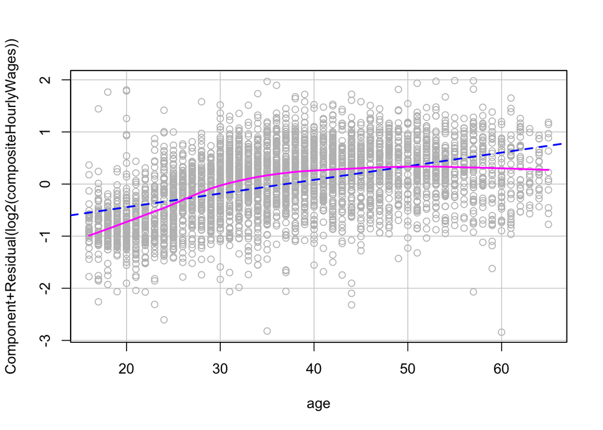

```r
# plot one at a time
# I didn't figure out how to change line colors...
crPlot(lmod.2, variable = "age", col = "grey",
       smooth = list(smoother=loessLine, span = 0.4, col = "black"))
```

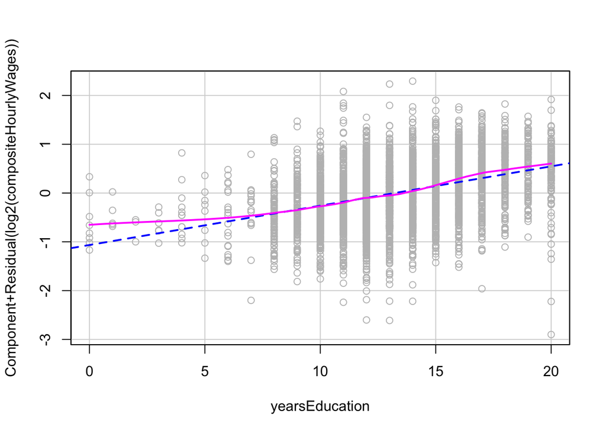

```r
crPlot(lmod.2, variable = "yearsEducation", col = "grey",
       smooth = list(smoother=loessLine, span = 0.4, col = "black"))
```

### write out your findings

**Answer**: (from JF 12.3.1) Both plots look nonlinear: It is not entirely clear whether the partial relationship of log wages to age is monotone, simply tending to level off at the higher ages, or whether it is nonmonotone, turning back down at the far right.

In the former event, we should be able to linearize the relationship by moving age **down** the ladder of powers because the bulge points to the left. In the latter event, a quadratic partial regression might work.

In contrast, the partial relationship of log wages to education is clearly monotone, and the departure from linearity is not great – except at the lowest levels of education, where data are sparse; we should be able to linearize this partial relationship by moving education **up** the ladder of powers, because the bulge points to the right.